# WK4 BIG DATA THE KEY TO THE 4TH INDUSTRIAL REVOLUTION

[interactive chart not shown]

Innovation in the Global Economy – 3

“Data” Key to Success of 4th Industrial Revolution

Today we see many government as well as private initiatives to

promote a data-based industrial revolution in the world. In the

“Industry 4.0” initiative in Germany, the government, industry and

academic institutes are all collaborating with each other in promoting

a strategy to achieve a more knowledge-intensive manufacturing

industry by using IoT (Internet of Things) — a system of mutual

control among the various product items through exchange of

information among themselves being connected to the Internet. In

the United States, the “Industrial Internet” initiative proposed by

General Electric is now in progress, that is an attempt to analyze Big

Data collected through IoT for future product development and

business activity.

The key to achieving the success of both initiatives is “Data”.

Therefore we call such initiatives a “Data-based Industrial

Revolution” and the perception is steadily prevailing today that a

Data-based Industrial Revolution will follow the Information and

Communication Technology (ICT) Revolution. The significantly rapid

progress of AI today symbolizes this development, as seen in the

victories of AI equipped with data over human champions in Go or

Shogi chess matches. A Go play software called “Alpha Go” created

by AI venture DeepMind kept winning over the human European

champions for five matches in a row from 2013 until 2015 and even

beat one of the best players in the world.

In addition, in the arena of financial investment, the development

of another use of AI is making progress. They are now working on

raising the capacity to predict stock prices in a few minutes by

AI equipped with Big Data on prices and transactions. If this attempt

is combined with another technological development such as “super

high-speed transaction” achieving thousands of transactions per

second, a program installed in a computer in advance, we will see a

drastic change of financial investment.

For example, Virtu Financial, a leading American electronic trading

firm, announced in March 2014 that it had a profit loss only for one

day in super high-speed transactions during 1,238 days. That

stunned the world market. However, such super high-speed

transactions would be soon combined with prediction techniques by

using AI and Big Data. Tremendous amounts of qualified data would

be key to achieving progress in AI and whoever can access Big Data

can control AI.

As is well known, there are other areas where the rapid progress

of the evolution of AI would play a key role. In the area of medical

science, by using AI, it is easier now to identify a cancer by image

data. We have a project in progress to support medical doctors in

their clinical judgements by pinpointing the cancer on the image.

There are some cases today where AI has found cancer that was not

apparent to a medical doctor’s naked eye. In such cases, I would like

to repeat that the data of images are the key to the success of the

project.

Since we are now living in an age when IoT and its related-product

markets are rapidly expanding, all kinds of data are being valued as

new assets all over the world. AI, Big Data analysis, 3D printers,

robots, and all such contemporary high technology products are

based upon data sets. Their active application in a wide range of

business and life purposes would mean “data” rule the world, and

this is what we call the Data-based Industrial Revolution.

In this revolution, the growth speed of markets closely related to

data is remarkable. According to Gartner Inc., an American IT

research and consultant company, the markets of Big Data, IoT and

AI are predicted to grow at 15% per annum, which is much higher

than the stagnant developed countries’ economic growth rate, the

ROE of Japanese business firms (around 8-9%) or expected returns

for Real Estate Investment Trusts (around 4-5%).

Among these markets, the application of Big Data is expected to

have a positive impact upon a variety of business fields, as the White

Paper on Telecommunications 2013 issued by Japan’s Ministry of

Internal Affairs and Communications described. For example, retail

business could provide customers with optimal products by using

data on customers’ behaviors and point-of-sale data systems.

Insurance companies could devise new insurance products based on

data on natural disasters and geographical data on disaster-hit areas,

and auto-insurance companies could set premium rates based on

data on driving. Hospitals could provide the best medical service

through data on medical consultations. Energy companies could

provide customers with electricity in the most efficient way by using

data on power consumption measured by smart meters. The

infrastructure business could reduce maintenance costs by using

data on the use of social capital or public facilities. The government

could provide private businesses with their owned data on public

policy to encourage them to use them for their own benefit.

To be more specific, NTT Docomo has now started a new business

selling its own Big Data for practical use. Komatsu Inc. has also

started to reduce production costs by 10% by an analysis of data on

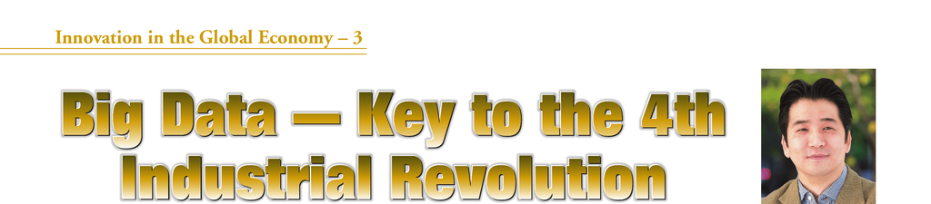

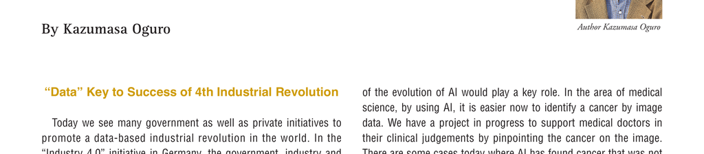

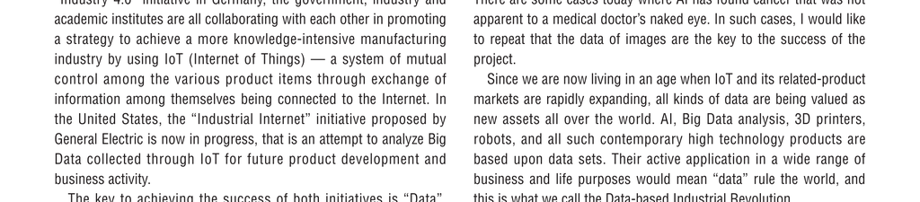

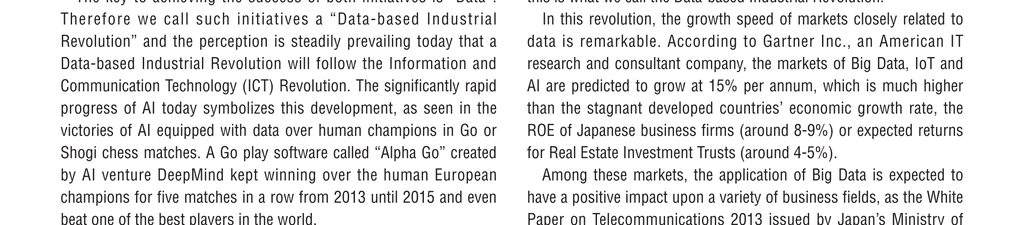

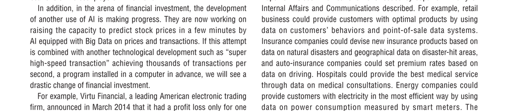

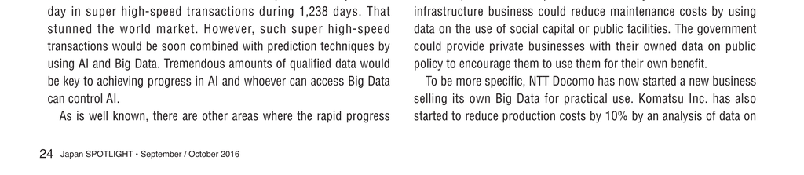

capacity utilization of mining production facilities all over the world

in collaboration with GE.

On the questions of healthcare (including care for beauty) and

longevity, if we can specify the factors determining longevity and

health by analysis of Big Data concerning people’s habits, eating

habits (including vitamins), professions, and salaries, as well as

hereditary information, the medical consultation business would gain

enormous benefits by using the outcomes of this analysis and grow

rapidly.

Recently in Japan, METI founded the “IoT Acceleration

Consortium” for promotion of Big Data, IoT, AI, etc. in an alliance

among industry, government and academia to achieve this goal. But

they have a long way to go and Japanese business and industry in

this high-technology area will need to be further consolidated to

prepare for the severe competition against the winners of the “ICT

revolution” — IT giants like Google and Amazon.

Integration of “Data” & “Finance” Beyond

“FinTech” Necessary

On April 12, 2016, Japanese Prime Minister Shinzo Abe gave the

opening speech at the Fifth Public-Private Dialogue towards

Investment for the Future related to the Fourth Industrial Revolution,

which included the following:

“Within this fiscal year, we will establish research and

development goals and a roadmap for the industrialization of artificial

intelligence. To that end, we will gather the wisdom of industry,

academia and the government, and create the non-vertically

segmented Artificial Intelligence Technology Strategy Council.

We will link regional venture businesses with the global market.

Within this fiscal year, we will create a private sector-led core

organization, and mobilize the policies of each ministry and agency

in a unified manner.

The first stage of the fourth industrial revolution was competition

relating to online data. The second stage will be competition relating

to real-world data, such as in manufacturing workplaces, where

Japan’s particular strengths lie. We will collect data that crosses the

boundaries of companies and organizations, analyze it, and link it to

business. We will transform the former principles of meeting in

person or conducting transactions in writing, and instead use the

new rule of the ‘IT Principle’. We will create ‘platforms’ for the

sharing and utilization of data in fields where Japan’s strengths can

be built upon.

By 2020, we will create advanced systems that share and utilize

data, which go beyond the boundaries of separate factories or

companies, collected by on-site sensors at 50 sites across Japan. By

cooperating with Germany, which shares with Japan strengths in

manufacturing bases, we will advance international standardization.

We will implement the practical application of automated driving

Target: new markets to enhance growth potential

— For realizing an economy of 600 trillion yen nominal GDP —

IoT, Big Data, AI, Robots

Key players in the 4th Industrial Revolution

market expected to total 30 trillion yen in 2020

Leader of the policy initiative “Public-Private Expert Council for Promotion of the Fourth Industrial Revolution”

Policies to be adopted:

Introduction of

deregulation

Promotion of data sharing

and utilization

— Creation of a common

platform for sharing and

utilizing Big Data beyond

companies and

organizations

— Strengthened support for

SMEs to promote IT

utilization

Creation of innovation in

Japan

— Creation of five R&D

centers with top-level

experts engaged in

promoting the most

advanced research

Human resources development to raise

creative and ambitious innovators

— Introduction of obligatory education for

computer programming in primary

schools

— Introduction of learning by the utilization

of IT through IT proficiency

— Prompt authorization process for

endowing non-Japanese experts with

green cards for the right to permanent

residence in Japan

Source: Council of Industrial Competitiveness of Japan

CHART 1

Roadmap towards 4th Industrial Revolution

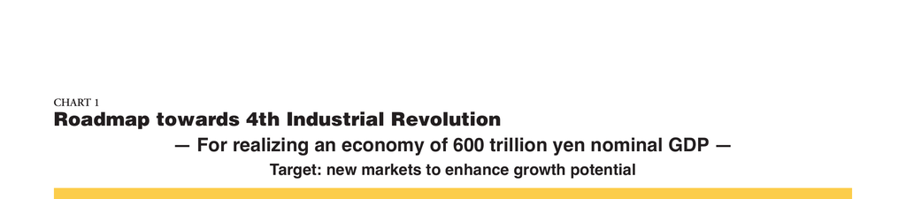

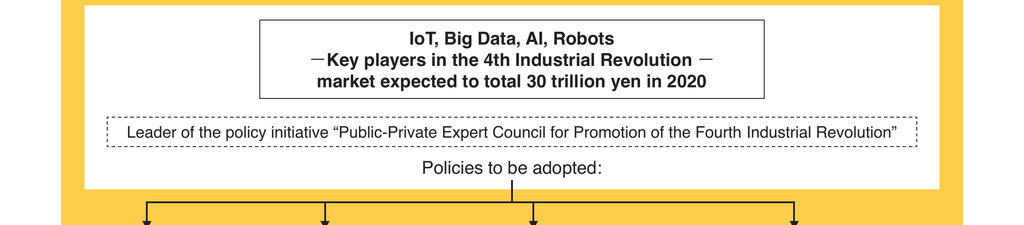

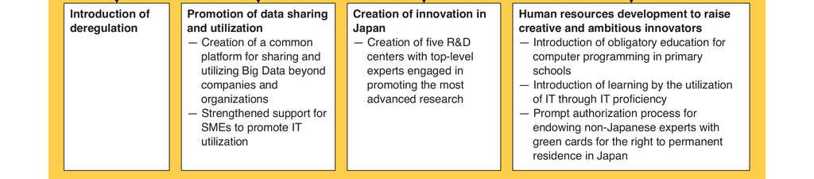

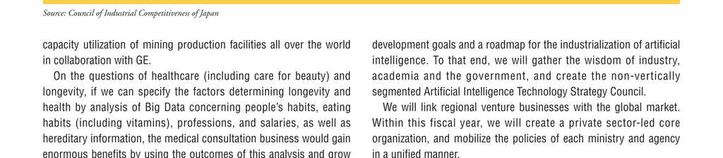

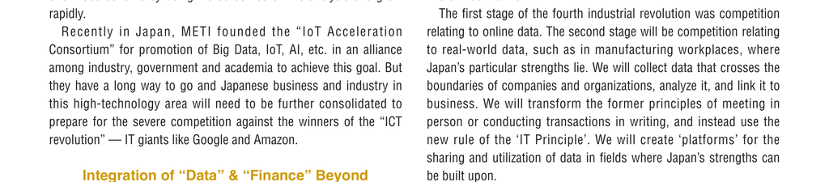

[figure not shown]

gather car manufacturers and map companies, unify specifications

that cross corporate boundaries, and conduct international

standardization. Within this year, we will streamline legal systems for

creating an organ that will efficiently collect large volumes of

treatment and test data, manage it, and maintain anonymity, so the

data can be used to further research on new drugs and treatments.

We will realize the provision of an ‘individualized health service’

that meets each individual’s needs. To that end, within this fiscal year

we will start verification operations to collect and analyze the data

related to health insurance claims, medical examinations, and health

that is currently held by medical institutions, companies, and

insurance companies. We will introduce measures to strengthen

initiatives by medical insurers that work to achieve preventative care

and promote health, including the verification operations.”

Abe also mentioned in his opening remarks at the 27th meeting of

the Council of Industrial Competitiveness on May 19, 2016 that the

key to the success of his growth strategy would be the Fourth

Industrial Revolution. With the emergence of IoT and robots there

would be new business opportunities and services to meet an

individual’s needs. The supply chain connected by IoT among shops

and factories could make it possible to supply goods immediately in

response to orders and thus make inventories unnecessary. This

would overhaul the nation’s industries. In order to take advantage of

this big opportunity, we will need to engage in structural reforms as

quickly as possible, otherwise this big opportunity will turn into a

crisis for the Japanese economy, as Japanese firms could become

subcontractors for the global companies successful in early reforms

in responding to this drastic change of the business environment

brought about by the Fourth Industrial Revolution.

Abe stressed the following three points as necessary structural

reforms in his speech. First, as was mentioned above, promotion of

a platform for sharing and using Big Data jointly among all

companies nationwide; second, pioneering regulatory reforms to

encourage innovation; and third, human resources development to

be a winner in the Fourth Industrial Revolution such as mandatory

education in computer programming in primary schools or

introducing proficiency in IT in such schools. With these reforms,

Abe committed to achieving an economy of 600 trillion yen

(Chart 1)

In spite of this clear and strong message to take full advantage of

the Fourth Industrial Revolution to achieve economic growth, I think

more will need to be done to encourage the expansive growth of

markets related to Big Data, IoT and AI.

My proposal is “integration of Big Data and Finance” going beyond

so called “FinTech”. “FinTech” is the utilization of IT in finance, such

as services, to enable customers to send money to a specific bank

account with only an ID used for social networks instead of the bank

account number. The prevailing smartphones are expanding the

utilization of such services. But what I would like to propose is not

limited to such a function of IT in finance. There will be the question

of legal data ownership arising from these expanding markets. We

can define such ownership as assets and create a fund for

securitization of those assets which would collect money from the

mass of investors all over the world and distribute dividends among

the investors. To realize this, we would need to accommodate a new

legal institution that has never been devised before

(Chart 2)

We have such a collective investment scheme for real estate

business, such as Real Estate Investment Trusts (REIT) or

securitization of real estate, and it is well known that legislative

reform to make it possible to achieve such a scheme was

instrumental in stimulating real estate development. Likewise, we

should provide a similar legal scheme to encourage collective

investment in the ownership of the collected data for Big Data, IoT

and AI. This could be called Big Data Investment Trust (BDIT). In this

case, we can include not only raw data but also the outcomes of data

analysis or predictions, a new data market to be created by AI, as

Big Data-related

market

AI program

Big Data,

etc

SPV

(Special Purpose Vehicle)

Financial market

Equity investment

Issuing non-recourse

loans or corporate

bonds

• preferred equity

investment

• investment in capital

of partnership

• purchase of

investment trusts

providing data

providing capital

interest & dividends

debt finance

equity finance

AI program

Big Data,

etc

(assets)

Debt

Equity

contribution of

revenues of analysis

paying money

for purchased data

Source: Compiled by the author

CHART 2

Basic structure of Big Data fund

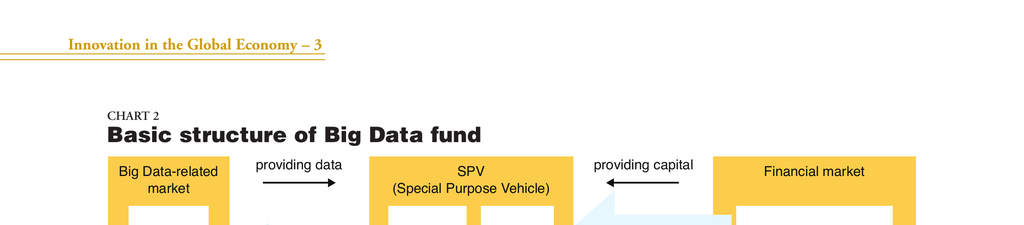

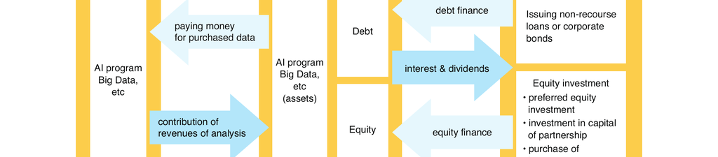

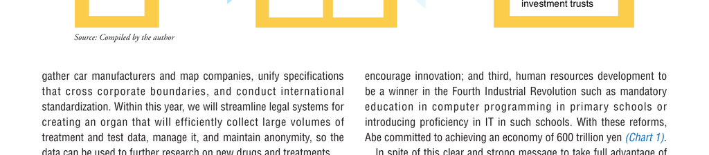

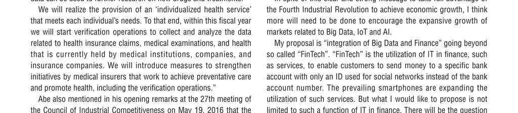

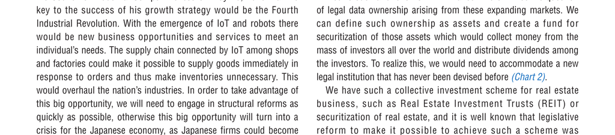

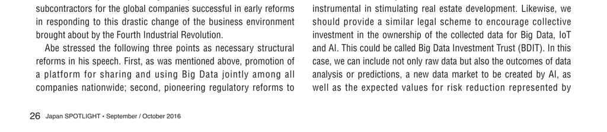

algorisms, in “the Asset” — changed from “Data”.

Why is this legal scheme so important for the Japanese economy?

The primary reason would be that we can stimulate the growth of Big

Data, IoT, AI and other related high-technology sectors without

increasing significantly our government expenditures for promoting

the Fourth Industrial Revolution. It is true that many of the

government policy initiatives programmed into the current policy

plan for Japanese growth are dependent on government budget

expenditures. However, as is well known, the Japanese government

is under strong pressure to observe budget constraints due to the

permanent fiscal deficit and cumulatively increasing debt.

The actual plan of fiscal consolidation of the Japanese

government, called “Basic Policy on Economic and Fiscal

Management and Reform 2015”, sets a goal for the primary balance

of the central and regional governments of being in surplus by 2020,

and also of curbing the deficit of the primary balance within 1% of

total GDP in 2018. With this scheme, private funds would be used to

stimulate the growth of those high-tech sectors to supplement or

replace the public expenditures. This scheme could also result in

vitalizing Japanese financial markets as well, since 1,700 trillion yen

of Japanese individuals’ financial assets as well as global assets

could find their most effective use. I think it would therefore be the

most effective growth stimulus for the new digitalized economy.

New Jobs & New Markets

Another reason why we would need this fund-raising scheme is

that R&D investment for these high-technologies such as Big Data,

IoT and AI would be enormous, since it would require large amounts

of money to collect and accommodate high-level large-scale

databases. So even though we can expect high profits from these

projects in the future, venture capitals could hesitate to provide

funds and in many cases they may not be able to earn sufficient

returns for data accommodation. For example, Toyota has already

announced the start of a study on AI in collaboration with Stanford

University and the Massachusetts Institute of Technology, and its

investment is estimated at around $50 million over five years.

The Japanese Ministry of Land, Infrastructure, Transport and

Tourism published its “Grand Design of National Spatial

Development towards 2050” in July 2014. This report made it clear

that the locations across the whole country where the population in

2050 is predicted to be less than half that of 2010 would account for

more than 60% of all residential areas.

Under such circumstances, it will be necessary to create a

quantitative indicator to promote compact cities, an urban planning

concept promoting relatively high residential density with mixed land

use based on an efficient public transport system, and efficient

maintenance of aged infrastructures. To achieve this, we would need

a Geographic Information System (GIS) that includes the population

diffusion by age or the utilization rates of various infrastructures in

the database. It should be noted, too, that the potential need for Big

Data to be applied to the cost-benefit analysis of this urban planning

would be rather high. Among such data, there must be not only data

on public goods but also many other data that would impose very

high costs for collection and accommodation on each business firm

involved in this project. There is a risk of a rapid increase in liability

in the balance sheet of a firm fund raising on its own. My proposal

for a “collective investment scheme” would be very useful in

enabling firms to earn funds without significantly increasing such

liability, since the necessary capital is collected from the mass of

investors.

In addition, I think this initiative could have a positive impact upon

employment. With the markets of these high-technologies vitalized

by this initiative, we could accelerate creation of new jobs such as

“data scientists” or “marketing technologists”. To be a winner in the

Data-based Industrial Revolution, we need to create not only “a

platform for sharing data” but also a platform for data specialists.

For example, “Deep Analytics” is a system that matches the needs

of data analysis and data scientists providing such analysis. In the

world today, crowdsourcing services for data analysis are

increasingly common, such as Kaggle, CrowdAnalytix, TunedIT,

Topcoder and InnoCentive. In particular, Kaggle, rapidly expanding in

the US, is a platform on the modeling of forecasts and analytical

methodologies where statisticians and data analysts from all over the

world are competing for the optimal analytical model by submitting

their ideas and findings to the site. The Japanese equivalent of

Kaggle would be Deep Analytics.

On the question of the confidentiality of data, a sensitive issue

today, we should take note that it will be necessary to do matching of

data and promoting data sharing while maintaining confidentiality in

the case of data not open to the public or that include personal

information to be protected. The Japanese government is currently

working on a policy to promote the use of anonymous data while

protecting personal information. With the revised Personal

Information Protection Law in Japan, partly put into practice since

January 2016, it has been made possible to utilize data including

personal information without the person’s permission on the

condition that firms make such information anonymous. The

government is now working on a new guideline on the extent to

which personal data must be concealed in order to make it possible

to be provided to a third party. When this guideline is fixed, we would

be able to accommodate an environment for mass data analysis in

Japan.

The global competition in the Fourth Industrial Revolution will be

highly intensive, as it will be competition to manage with the

incomparably rapid progress of AI, IoT and Big Data. We must be

more creative than ever in formulating growth strategies in such a

rapidly growing digital market. We must think about how effectively

our resources can be used for this purpose. The proposal I have

introduced here shows, I believe, that Japanese excess savings in

the business sector could be used efficiently for the appropriate

goals.

Kazumasa Oguro is a professor of the Faculty of Economics at Hosei

University and consulting fellow at the Research Institute of Economy, Trade &

Industry at METI.

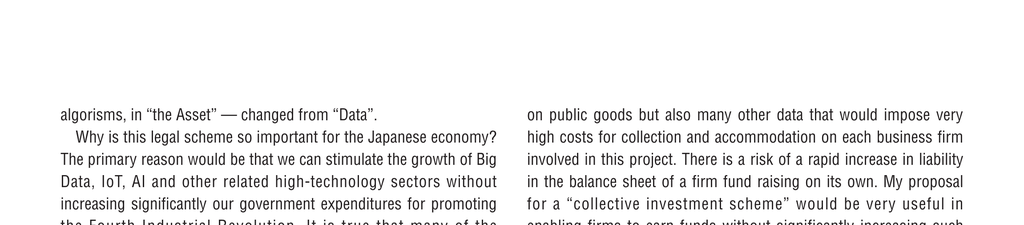

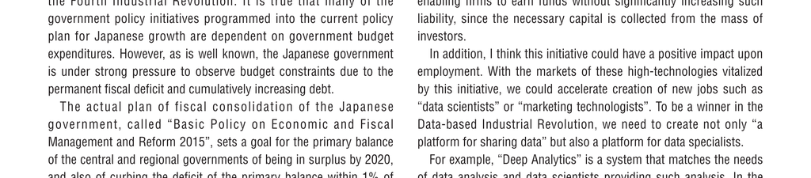

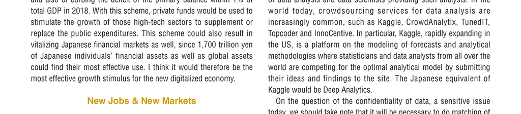

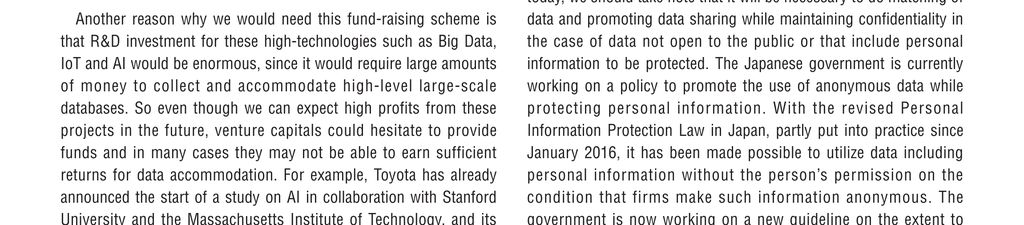

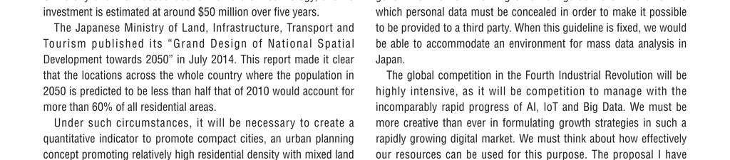

[figure not shown]

[figure not shown]

[figure not shown]